# Randomization and Function Plotting

Colleen Yancey

April 4, 2018

```r
library(ggplot2)
```

### Editting the Class code to our own function

In my research I use a fungal hyphal length equation to help determine average hyphae length in soil samples. This is important in understanding fungal activity, and soil health. Knowing the length of these hyphae can help you to determine relative growth rates, and compare hyphae presence from different soils. It is a very basic equation that I have used a lot. The data retrieval can be really annoying (counting little pink squiggles on a microscope that intersect a grid line) but can be very informative overall.  
Below is the code I have modified for hyphal length analysis.

```r
# Hyphal Lenght analysis
# 27 March 2018
# CEY

# The equation: HL = ll/14*N*g gives you hyphal root length
##################################################
# FUNCTION: HyphaeLen
# determines average hyphae root length in a soil sample
# input: N = number of intersections across vertical and horizontal lines
#        g= gird unit length of section (cm)
#        C = predetermined constant (done by Tennet, 1975
# output: root length
#-------------------------------------------------

HyphaeLen <- function(N=20:200,c=(11/14),g=.05){
  HL <-N*c*g
  return(HL)
}
head(HyphaeLen())
```

```
## [1] 0.7857143 0.8250000 0.8642857 0.9035714 0.9428571 0.9821429
```

Now I am going to create a function to plot this data

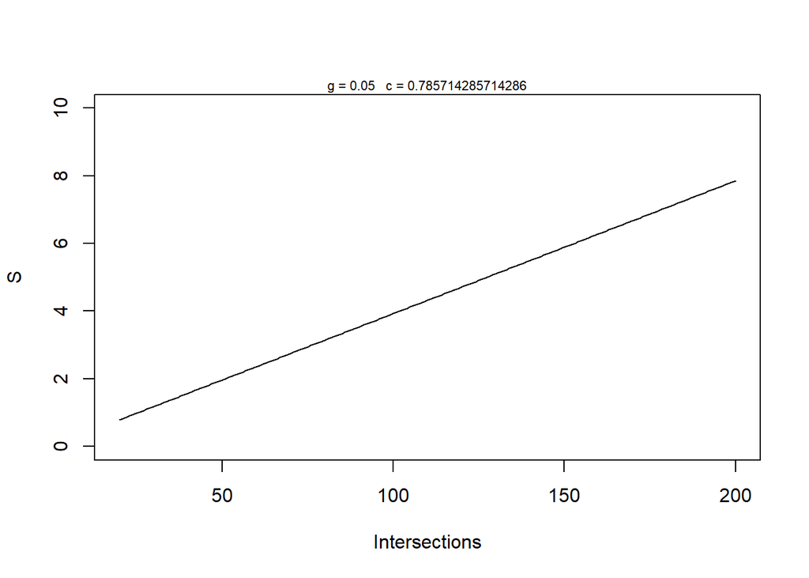

```r
#######################
# FUNCTION: HyphaeLenPlot
# plot hyphae length curves with parameter values
# input: N= number of intersections across vertical and horizontal lines
#       g= grid unit length (cm)
#       c= predetermined constant (done by Tennet 1975)
#output: smoothed curve with parameters in the graph
#-----------------------------------------

HyphaeLenPlot <- function(N=20:200, c=11/14, g=0.05){
 plot(x=N,y=HyphaeLen(N,g,c),type="l",xlab="Intersections",ylab="S",ylim=c(0,10))
mtext(paste("g =", g,"  c =",c),cex=0.7)
      return()
}
HyphaeLenPlot()
```

### Now build a grid of plots!

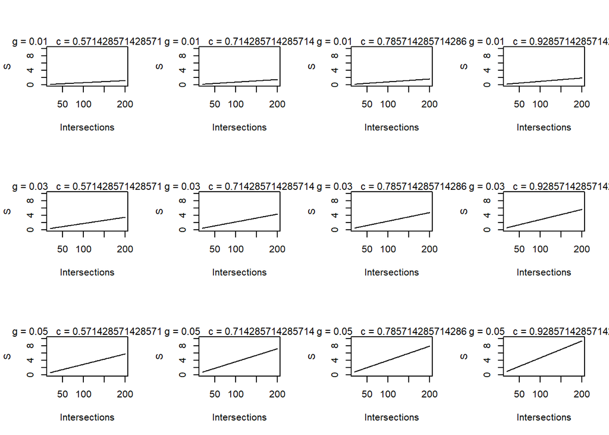

```r
gPars <- c(.01, .03, .05)
cPars <- c(8/14, 10/14, 11/14, 13/14)
par(mfrow=c(3,4))
for(i in seq_along(gPars)){
  for(j in seq_along(cPars)){
    HyphaeLenPlot(g=gPars[i], c=cPars[j])
  }
}
```

###Using the `expand.grid()` function to create a dataframe with parameter combinations

```r
modelFrame<-expand.grid(gPars, cPars)
modelFrame$S<- NA
modelFrame
```

```
##    Var1      Var2  S
## 1  0.01 0.5714286 NA
## 2  0.03 0.5714286 NA
## 3  0.05 0.5714286 NA
## 4  0.01 0.7142857 NA
## 5  0.03 0.7142857 NA
## 6  0.05 0.7142857 NA
## 7  0.01 0.7857143 NA
## 8  0.03 0.7857143 NA
## 9  0.05 0.7857143 NA
## 10 0.01 0.9285714 NA
## 11 0.03 0.9285714 NA
## 12 0.05 0.9285714 NA
```

### Parameter sweeping redux with `ggplot2` graphics

```r
Area <- 1:5 #keep this very small initially
cPars <- c(50,80,120)
zPars <- c(11/14, 13/14, 9/14, 10/14)

HyphaeLength <- function(A=1:5000,c= 0.5,z=0.26){

  S <- c*(A^z)
return(S)
}
head(HyphaeLength())
```

```
## [1] 0.5000000 0.5987394 0.6653061 0.7169776 0.7598051 0.7966899
```

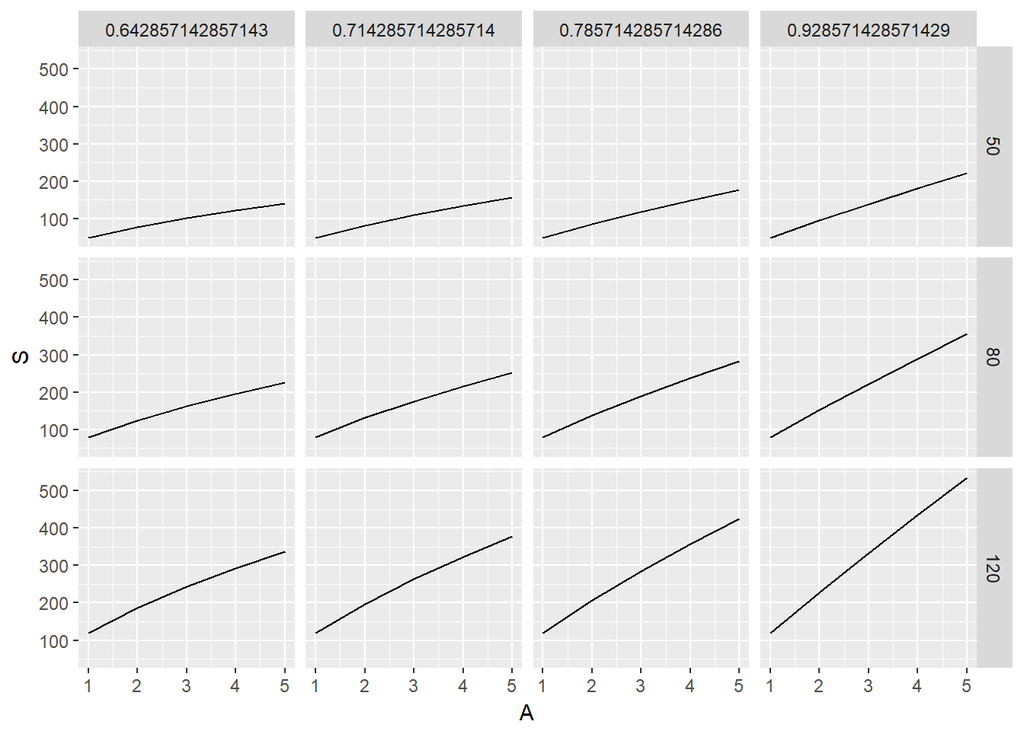

```r
# set up model frame
modelFrame <- expand.grid(c=cPars,z=zPars,A=Area)
modelFrame$S <- NA


# loop through the parameters and fill with SA function

for (i in 1:length(cPars)) {
  for (j in 1:length(zPars)) {
    modelFrame[modelFrame$c==cPars[i] & modelFrame$z==zPars[j],"S"] <-   HyphaeLength(A=Area,c=cPars[i],z=zPars[j])
  }
}
# print(modelFrame) # check by printing a data frame with limited parameter values

library(ggplot2)

p1 <- ggplot(data=modelFrame)
p1 + geom_line(mapping= aes(x=A,y=S)) +
  facet_grid(c~z)
```

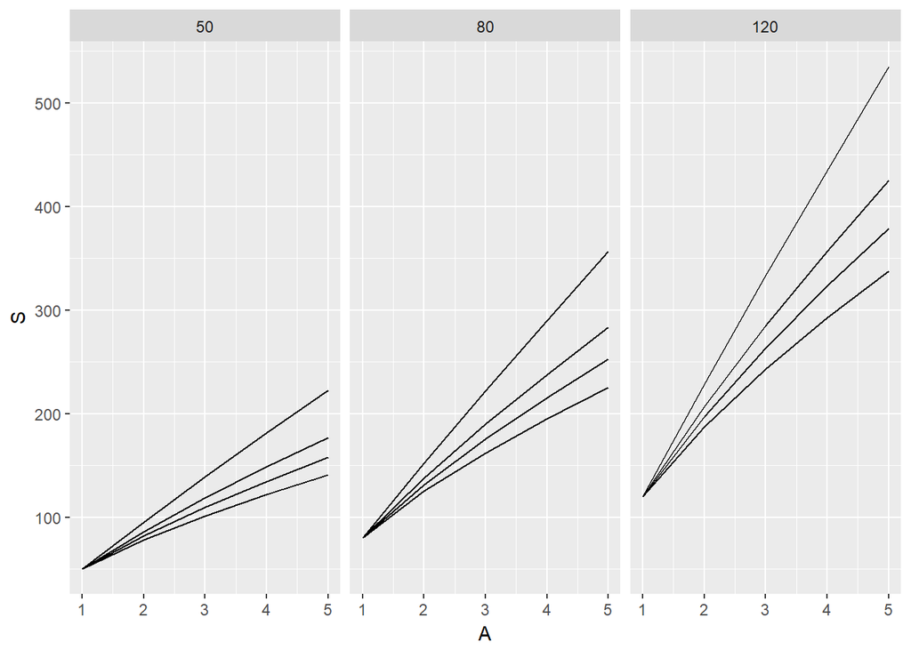

```r
p2 <- p1
p2 + geom_line(mapping=aes(x=A,y=S,group=z)) +
  facet_grid(.~c)
```

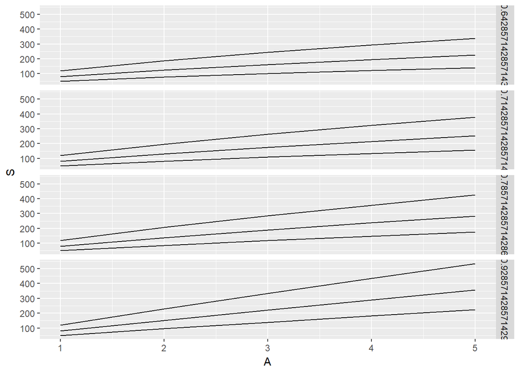

```r
p3 <- p1
p3 + geom_line(mapping=aes(x=A,y=S,group=c)) +
  facet_grid(z~.)
```

Conducting A randomization test for my own data

```r
#preliminaries
library(ggplot2)
library(TeachingDemos)
char2seed("Cruel April")

#############################################
#FUNCTION: readData
# read in or generate data frame, will get changed most when you work with it in future
# input filename (or nothing for demo)
#output: 3-column data frame of observed data:
#dat:(ID,x,y)
#--------------------------------------------------

readData <- function(z=NULL){
  if(is.null(z)){
    xVar <- c(0,6,13,19)
    yVar <- c(8.947,8.289,6.346,3.766)
    dF <- data.frame(ID=seq_along
                     (xVar), xVar, yVar)
    return(dF)}
}


#preliminary data on AMF colonization regression, imcomlete, but I think it'll work for this purpose. X is icing treatment (mm thick of ice, and y is AMF structures/cm

readData()
```

```
##   ID xVar  yVar
## 1  1    0 8.947
## 2  2    6 8.289
## 3  3   13 6.346
## 4  4   19 3.766
```